# Survival Model Replications

Andrew Fogarty

8/2/2019

# 1 Introduction

Survival models are an important quantitative tool with myriad applications in political research. Within the field of Comparative Politics, survival models are heavily used to model democratic breakdown. Typically, political scientists use survival models to derive the average number of years a democratic regime survives, given a variable of interest. While survival models incorporate many different estimators, the most common is the Cox proportional hazards model, `coxph()`. This document replicates an Journal of Politics article published by Maeda, titled: [Two Modes of Democratic Breakdown: A Competing Risks Analysis of Democratic Durability](https://www.researchgate.net/profile/Ko_Maeda/publication/231823944_Two_Modes_of_Democratic_Breakdown_A_Competing_Risks_Analysis_of_Democratic_Durability/links/544a5b4e0cf2fc851ede73a9.pdf). Since Maeda’s analysis was conducted in Stata, we will replicate his work in R. His data and Stata analysis can be found on his [website](http://politicalscience.unt.edu/~maeda/).

# 2 Data

We begin by loading some libraries, the panel data, and initiating a summary of the variables.

```r
# load libraries
library(survival)
library(coxed)
library(survminer)
library(tidyr)
library(dplyr)
library(plotly)
library(MASS)
```

```r
# load data
df <- read.csv('https://raw.githubusercontent.com/afogarty85/replications/master/Maeda/MaedaCSV.csv')
```

```r
# review data
summary(df)
```

```
##      ccode             country           year          month
##  Min.   :  2.0   Australia :  708   Min.   :1946   Min.   : 1.00
##  1st Qu.:165.0   Belgium   :  708   1st Qu.:1969   1st Qu.: 4.00
##  Median :349.0   Canada    :  708   Median :1986   Median : 7.00
##  Mean   :383.6   Costa Rica:  708   Mean   :1982   Mean   : 6.53
##  3rd Qu.:590.0   Denmark   :  708   3rd Qu.:1996   3rd Qu.:10.00
##  Max.   :950.0   Finland   :  708   Max.   :2004   Max.   :12.00
##                  (Other)   :26119
##      demid            demend           endmode            demmonth
##  Min.   :  1.00   Min.   :0.00000   Min.   :0.000000   Min.   :   1.0
##  1st Qu.: 36.00   1st Qu.:0.00000   1st Qu.:0.000000   1st Qu.:  72.0
##  Median : 76.00   Median :0.00000   Median :0.000000   Median : 193.0
##  Mean   : 81.24   Mean   :0.02993   Mean   :0.002173   Mean   : 366.4
##  3rd Qu.:121.00   3rd Qu.:0.00000   3rd Qu.:0.000000   3rd Qu.: 501.0
##  Max.   :165.00   Max.   :9.00000   Max.   :2.000000   Max.   :2350.0
##
##      polity             ope               gro                urb
##  Min.   :-88.000   Min.   :  1.867   Min.   :-41.8000   Min.   :  3.80
##  1st Qu.:  8.000   1st Qu.: 29.876   1st Qu.:  0.1192   1st Qu.: 42.80
##  Median : 10.000   Median : 48.381   Median :  2.2773   Median : 61.38
##  Mean   :  8.559   Mean   : 58.969   Mean   :  2.1649   Mean   : 57.52
##  3rd Qu.: 10.000   3rd Qu.: 82.093   3rd Qu.:  4.4593   3rd Qu.: 74.66
##  Max.   : 10.000   Max.   :221.603   Max.   : 56.0741   Max.   :100.00
##                    NA's   :1288      NA's   :1870       NA's   :98
##    prereg_ind       prereg_mil       regiondem         preparmix
##  Min.   :0.0000   Min.   :0.0000   Min.   :-6.9048   Min.   :1.000
##  1st Qu.:0.0000   1st Qu.:0.0000   1st Qu.:-0.2917   1st Qu.:1.000
##  Median :0.0000   Median :0.0000   Median : 1.8800   Median :2.000
##  Mean   :0.2656   Mean   :0.1602   Mean   : 2.3765   Mean   :1.849
##  3rd Qu.:1.0000   3rd Qu.:0.0000   3rd Qu.: 6.2000   3rd Qu.:2.000
##  Max.   :1.0000   Max.   :1.0000   Max.   : 8.1154   Max.   :3.000
##
##       enp            majgovm           presi            mixed
##  Min.   : 1.000   Min.   :0.0000   Min.   :0.0000   Min.   :0.0000
##  1st Qu.: 2.170   1st Qu.:0.0000   1st Qu.:0.0000   1st Qu.:0.0000
##  Median : 2.830   Median :1.0000   Median :0.0000   Median :0.0000
##  Mean   : 3.326   Mean   :0.7353   Mean   :0.2653   Mean   :0.1142
##  3rd Qu.: 3.970   3rd Qu.:1.0000   3rd Qu.:1.0000   3rd Qu.:0.0000
##  Max.   :24.897   Max.   :1.0000   Max.   :1.0000   Max.   :1.0000
##  NA's   :1508     NA's   :145
```

[output cut: 41 more lines]

```
##  Min.   :-41.837   Min.   :0.000   Min.   :0.0000   Min.   :0.000
##  1st Qu.: -1.211   1st Qu.:4.277   1st Qu.:0.0000   1st Qu.:0.000
##  Median :  9.743   Median :5.263   Median :0.0000   Median :0.000
##  Mean   : 12.743   Mean   :5.137   Mean   :0.3945   Mean   :2.002
##  3rd Qu.: 26.899   3rd Qu.:6.217   3rd Qu.:1.0000   3rd Qu.:4.682
##  Max.   : 58.810   Max.   :7.762   Max.   :1.0000   Max.   :7.762
##
##      impose
##  Min.   :0.0000
##  1st Qu.:0.0000
##  Median :0.0000
##  Mean   :0.2133
##  3rd Qu.:0.0000
##  Max.   :1.0000
##
```

```r
table(df$demend)
```

```
##
##     0     1     9
## 30226    45    96
```

We can visualize the duration of democratic regimes by plotting `demmonth` as a histogram. It shows that the prospects for democracy are not great since nearly half of the regimes in our sample do not survive past 16 years.

```r
df_hist <- df %>% group_by(country) %>% summarize_at(vars(demmonth), list(max))

plot_ly(data = df_hist, type = 'histogram') %>%
  add_trace(x = ~demmonth, name  = "Duration of Survival", nbinsx = 40) %>%
  layout(xaxis = list(
    title = '# of Months'),
    yaxis = list(
      title = 'Count'))
```

[interactive chart not shown]

# 3 Kaplan-Meier Curve

Since we have panel data, there are a few extra steps we must take so that it can be analyzed correctly. What we are going to do next is replicate the `stset` command in Stata by creating two variables, a `start_time` and `end_time`, which increases in count every observation until breakdown (failure). Once a democracy breaksdown, the counter should reset. To do this easily, we need a variable in our dataset that represents a unique number for each country during its survival spell. If a democratic regime fails multiple times within a single country, it should have multiple unique numbers. Maeda created a variable, `demid`, that does just this. The `start_time` and `end_time` calculation proceeds as follows:

```r
## start time
df <- df %>%
  group_by(demid) %>%
  mutate(start_time = 0:(n() - 1))
df <- ungroup(df)

## end time
df <- df %>%
  group_by(demid) %>%
  mutate(end_time = 1:(n()))
df <- ungroup(df)
```

Now we can display our first survival curve. The Kaplan-Meier Curve displays the number of democracies still surviving at each month of measurement. It plots our sample’s dependent variable while taking into account no predictors. The graph is interpreted as follows: At `x` months, the probability an average democratic regime is still surviving is approximately `x`%.

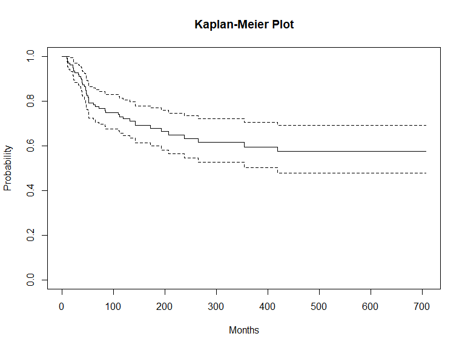

```r
km.curve <- Surv(time = df$start_time, time2 = df$end_time, event = df$demend)
plot(km.curve, main="Kaplan-Meier Plot", xlab="Months", ylab="Probability")
```

The cumulative hazard function expresses the risk of democratic regime breakdown. The graph is interpreted as follows: At `x` months, the risk an average democratic regime will suffer from breakdown is approximately `x` %.

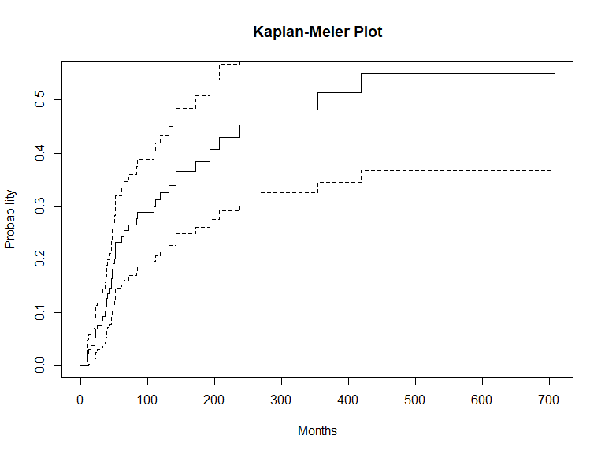

```r
km.curve <- Surv(time = df$start_time, time2 = df$end_time, event = df$demend)
plot(km.curve, main="Kaplan-Meier Plot", xlab="Months", ylab="Probability", fun = "cumhaz")
```

# 4 Cox Proportional Hazards Model

We use a Cox proportional hazard model when our dependent variable consists of observations of durations. Cox models assume a proportional hazards assumption, an assumption that we will test later, which means that the baseline hazard does not vary across observations. Before fitting our first model, we need to make a few more alterations to replicate Maeda’s results.

```r
# make a new DV since Maeda used 9 for censors that Stata ignores but R does not
df <- df %>% mutate(demend2 = ifelse(demend == 9, 0, demend))
```

Next, we replicate Maeda’s first model. Our results are close, but not a perfect match, which is generally expected when comparing replications conducted across statistical platforms.

```r
cox.model <- coxph(Surv(time = df$start_time, time2 = df$end_time, event = df$demend2) ~ dev + gro
                   + presi + mixed + majgovm + ethnic + ope + urb + prereg_ind
                   + prereg_mil + regiondem + postcw + impose
                   + cluster(country), method = 'efron', robust = TRUE, data=df)
summary(cox.model)
```

```
## Call:
## coxph(formula = Surv(time = df$start_time, time2 = df$end_time,
##     event = df$demend2) ~ dev + gro + presi + mixed + majgovm +
##     ethnic + ope + urb + prereg_ind + prereg_mil + regiondem +
##     postcw + impose + cluster(country), data = df, robust = TRUE,
##     method = "efron")
##
##   n= 28468, number of events= 42
##    (1899 observations deleted due to missingness)
##
##                 coef exp(coef)  se(coef) robust se      z Pr(>|z|)
## dev        -0.795809  0.451216  0.326401  0.308732 -2.578  0.00995 **
## gro        -0.075652  0.927139  0.024925  0.031597 -2.394  0.01665 *
## presi       0.483778  1.622191  0.515306  0.685603  0.706  0.48042
## mixed       0.323106  1.381412  0.661309  0.963750  0.335  0.73743
## majgovm    -0.570004  0.565523  0.365604  0.328207 -1.737  0.08244 .
## ethnic     -0.863002  0.421894  0.817360  0.789523 -1.093  0.27436
## ope        -0.008674  0.991363  0.004823  0.005051 -1.717  0.08592 .
## urb        -0.013321  0.986768  0.014351  0.012816 -1.039  0.29861
## prereg_ind  0.173090  1.188973  0.539798  0.697114  0.248  0.80391
## prereg_mil  0.033813  1.034391  0.440014  0.410861  0.082  0.93441
## regiondem  -0.076098  0.926726  0.073657  0.078256 -0.972  0.33084
## postcw     -0.016099  0.984029  0.492071  0.420049 -0.038  0.96943
## impose     -0.136393  0.872499  0.505563  0.360944 -0.378  0.70552
## ---
## Signif. codes:  0 '***' 0.001 '**' 0.01 '*' 0.05 '.' 0.1 ' ' 1
##
##            exp(coef) exp(-coef) lower .95 upper .95
## dev           0.4512     2.2162   0.24637    0.8264
## gro           0.9271     1.0786   0.87146    0.9864
## presi         1.6222     0.6165   0.42317    6.2185
## mixed         1.3814     0.7239   0.20892    9.1342
## majgovm       0.5655     1.7683   0.29722    1.0760
## ethnic        0.4219     2.3703   0.08978    1.9827
## ope           0.9914     1.0087   0.98160    1.0012
## urb           0.9868     1.0134   0.96229    1.0119
## prereg_ind    1.1890     0.8411   0.30324    4.6618
## prereg_mil    1.0344     0.9668   0.46234    2.3142
## regiondem     0.9267     1.0791   0.79495    1.0803
## postcw        0.9840     1.0162   0.43198    2.2416
## impose        0.8725     1.1461   0.43006    1.7701
##
## Concordance= 0.782  (se = 0.038 )
## Likelihood ratio test= 50.6  on 13 df,   p=2e-06
## Wald test            = 71.22  on 13 df,   p=5e-10
## Score (logrank) test = 53.88  on 13 df,   p=6e-07,   Robust = 28.96  p=0.007
##
##   (Note: the likelihood ratio and score tests assume independence of
##      observations within a cluster, the Wald and robust score tests do not).
```

# 5 Non Parametric Step Function (NPSF) Analysis

We use a NPSF to generate myriad statistics and make comparisons between variables of interest. Since we have panel data, we need to specify `id` in the function below.

```r
npsf.model <- coxed(cox.model, method="npsf", id = df$country) # fit NPSF
```

By using the `exp.dur` attribute, we can retrieve the predicted duration for each country

```r
head(npsf.model$exp.dur)
```

```
##    exp.dur
## 1 630.0588
## 2 630.0588
## 3 630.0588
## 4 630.0588
## 5 630.0588
## 6 630.0588
```

We can also generate the mean or median for our sample, by specifying the proper statistic. The predicted mean duration of democratic regime survival is 543 months or 45 years.

```r
summary(npsf.model, stat="mean")
```

```
##    mean
## 543.205
```

```r
summary(npsf.model, stat="median")
```

```
## median
## 608.54
```

The NPSF also provides useful means for deriving the cumulative baseline hazard function and the baseline survivor function. We retrieve this data by specifying the `baseline.functions` attribute.

```r
head(npsf.model$baseline.functions)
```

```
##   time cbh survivor
## 1    1   0        1
## 2    2   0        1
## 3    3   0        1
## 4    4   0        1
## 5    5   0        1
## 6    6   0        1
```

We can also readily graph this data in a few steps. Following a similar interpretation from the `Kaplan-Meier Curve` section, `cbh` tells us the risk of a democratic regime suffering from breakdown over time; assuming all covariates are 0. The next panel, `survivor`, tells us the probability that a democratic regime is still surviving by `x` months.

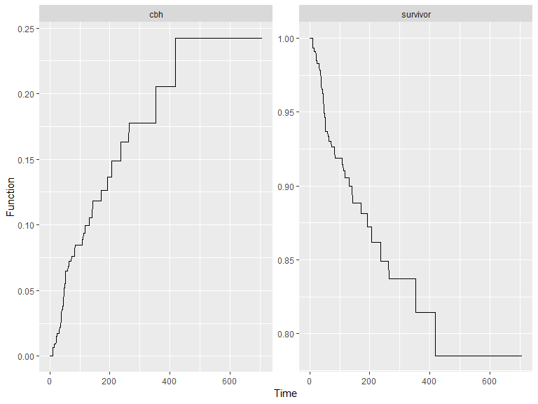

```r
baseline <- gather(npsf.model$baseline.functions, cbh, survivor, key="survivefunction", value="value")
ggplot(baseline, aes(x=time, y=value)) +
     geom_line() +
     xlab("Time") +
     ylab("Function") +
     facet_wrap( ~ survivefunction, scales = "free")
```

## 5.1 Out of Sample Predictions

We can also generate out of sample predictions. Let’s say we want to know how long a hypothetical or actual democratic regime is likely to survive that was not included in our dataset. We can specify the exact value for our variable of interest, in this case `dev` (GDP) following Maeda, while specifying all other values remain constant at our sample’s mean.

```r
new.country <- data.frame(dev = 9.5,
                            gro = mean(na.omit(df$gro)),
                            presi = mean(na.omit(df$presi)),
                            mixed = mean(na.omit(df$mixed)),
                            majgovm = mean(na.omit(df$majgovm)),
                            ethnic = mean(na.omit(df$ethnic)),
                            ope = mean(na.omit(df$ope)),
                            urb = mean(na.omit(df$urb)),
                            prereg_ind = mean(na.omit(df$prereg_ind)),
                            prereg_mil = mean(na.omit(df$prereg_mil)),
                            regiondem = mean(na.omit(df$regiondem)),
                            postcw = mean(na.omit(df$postcw)),
                            impose = mean(na.omit(df$impose)))

forecast <- coxed(cox.model, newdata=new.country, method="npsf", id = df$country, bootstrap=TRUE, B=30)
forecast$exp.dur
```

```
##    exp.dur bootstrap.se       lb       ub
## 1 637.6422     15.56594 607.1335 668.1509
```

## 5.2 Marginal Changes in Expected Duration

We can also compare two values within our variable of interest. Let’s say we are interested in determining the difference in democratic survival duration between a country with high GDP and a country with low GDP. We can specify two new dataframes where all cases receive either high or low GDP. We use the `min` and `max` as sufficient values for high and low. We would increase `B` to iterate many more times for more reliable results.

```r
min(na.omit(df$dev))
```

```
## [1] 5.815288
```

```r
max(na.omit(df$dev))
```

```
## [1] 10.45954
```

```r
marginal.changes <- coxed(cox.model, method = "npsf", id = df$country, bootstrap = TRUE, B = 5,
            newdata =  dplyr::mutate(df, dev = 5.8),
            newdata2 = dplyr::mutate(df, dev = 10.5))
```

Our results are interpreted as follows: A democratic regime with a high GDP such that `dev = 10.5` will survive for 500 more months, on average, than a democratic regime with a low GDP, such that `dev = 5.8`.

```r
summary(marginal.changes, stat="mean")
```

```
##               mean bootstrap.se      lb      ub
## newdata2   667.094        3.915 659.421 674.767
## newdata    166.637       18.809 129.772 203.503
## difference 500.457       14.956 471.144 529.770
```

```r
summary(marginal.changes, stat="median")
```

```
##             median bootstrap.se      lb      ub
## newdata2   674.118        3.320 667.611 680.624
## newdata    133.152       21.165  91.670 174.634
## difference 538.173       16.691 505.460 570.886
```

# 6 Survival Curves

We can also visualize the marginal changes over time with the help of `survminer`. What we are doing in the code below is comparing the difference in survival duration between two democratic regimes with high and low GDP, while holding all other variables constant at the sample mean.

```r
# Create the new data
new_data <- data.frame(dev = c(5.8, 10.5),
                            gro = mean(na.omit(df$gro)),
                            presi = mean(na.omit(df$presi)),
                            mixed = mean(na.omit(df$mixed)),
                            majgovm = mean(na.omit(df$majgovm)),
                            ethnic = mean(na.omit(df$ethnic)),
                            ope = mean(na.omit(df$ope)),
                            urb = mean(na.omit(df$urb)),
                            prereg_ind = mean(na.omit(df$prereg_ind)),
                            prereg_mil = mean(na.omit(df$prereg_mil)),
                            regiondem = mean(na.omit(df$regiondem)),
                            postcw = mean(na.omit(df$postcw)),
                            impose = mean(na.omit(df$impose)))
new_data
```

```
##    dev      gro     presi   mixed   majgovm    ethnic      ope      urb
## 1  5.8 2.164882 0.2653209 0.11417 0.7353253 0.3349172 58.96876 57.52368
## 2 10.5 2.164882 0.2653209 0.11417 0.7353253 0.3349172 58.96876 57.52368
##   prereg_ind prereg_mil regiondem    postcw    impose
## 1  0.2656173  0.1601739  2.376494 0.3944743 0.2133237
## 2  0.2656173  0.1601739  2.376494 0.3944743 0.2133237
```

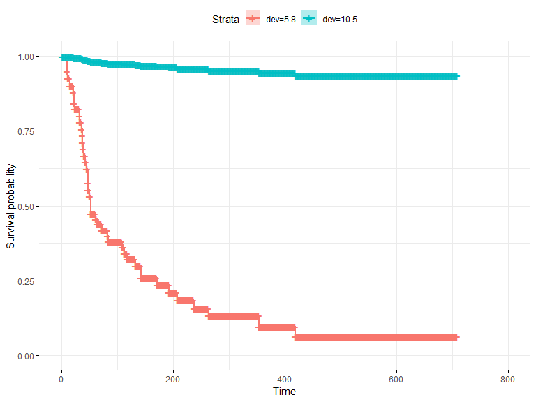

```r
# Survival curves
fit <- survfit(cox.model, newdata = new_data)
ggsurvplot(fit, conf.int = TRUE, legend.labs=c("dev=5.8", "dev=10.5"),
           ggtheme = theme_minimal(), data = df)
```

# 7 Check Cox Assumptions

```r
test.ph <- cox.zph(cox.model) # non significant relationship is ideal
test.ph
```

```
##                 rho   chisq       p
## dev         0.06135  0.2425 0.62238
## gro        -0.08973  1.3335 0.24819
## presi       0.00728  0.0108 0.91712
## mixed      -0.02963  0.1710 0.67926
## majgovm    -0.05276  0.1452 0.70312
## ethnic      0.11794  1.7305 0.18835
## ope         0.07980  0.7818 0.37660
## urb         0.29061  4.8138 0.02823
## prereg_ind  0.03660  0.2608 0.60960
## prereg_mil -0.05576  0.2299 0.63158
## regiondem  -0.34108 10.1134 0.00147
## postcw      0.36329 10.0216 0.00155
## impose      0.28839  2.0901 0.14825
## GLOBAL           NA 22.2739 0.05126
```

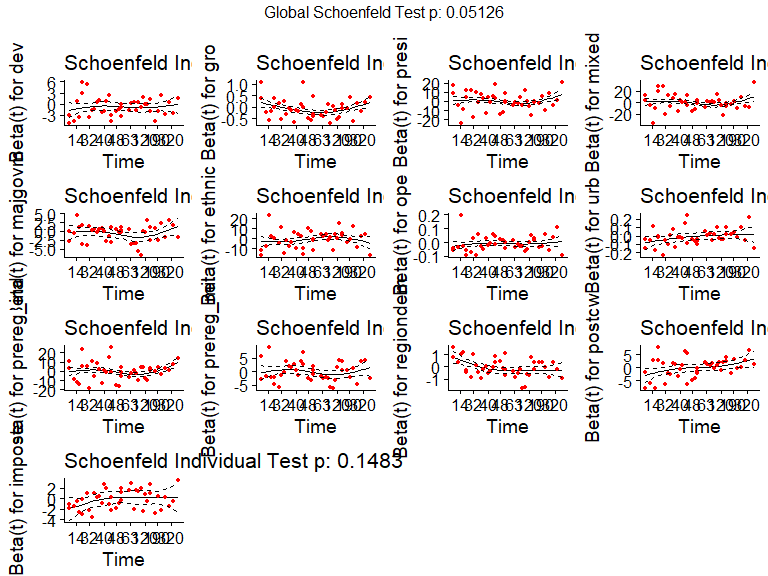

```r
ggcoxzph(test.ph)
```

# 8 Stepwise Model Selection

We can also use a stepwise algorithm to help us find the best fitting model if we wanted to completely discard the theory and qualitative nature behind Maeda’s model selection.

```r
df2 <- na.omit(df) # a little heavy-handed, but stepAIC will not work with NAs

cox.model <- coxph(Surv(time = df2$start_time, time2 = df2$end_time, event = df2$demend2) ~ dev + gro
                   + presi + mixed + majgovm + ethnic + ope + urb + prereg_ind
                   + prereg_mil + regiondem + postcw + impose
                   + cluster(country), method = 'efron', robust = TRUE, data=df2)

stepwise2 <- stepAIC(cox.model, direction = 'backward')
```

```
## Start:  AIC=289.48
## Surv(time = df2$start_time, time2 = df2$end_time, event = df2$demend2) ~
##     dev + gro + presi + mixed + majgovm + ethnic + ope + urb +
##         prereg_ind + prereg_mil + regiondem + postcw + impose +
##         cluster(country)
##
##
## Step:  AIC=289.48
## Surv(time = df2$start_time, time2 = df2$end_time, event = df2$demend2) ~
##     dev + gro + presi + mixed + majgovm + ethnic + ope + urb +
##         prereg_ind + prereg_mil + regiondem + postcw + impose
##
##              Df    AIC
## - postcw      1 287.51
## - mixed       1 287.52
## - impose      1 287.54
## - prereg_mil  1 287.57
## - prereg_ind  1 287.58
## - presi       1 288.80
## - urb         1 288.80
## - regiondem   1 288.80
## - majgovm     1 288.90
## - ethnic      1 288.96
## <none>          289.49
## - ope         1 291.25
## - gro         1 292.46
## - dev         1 295.35
##
## Step:  AIC=287.51
## Surv(time = df2$start_time, time2 = df2$end_time, event = df2$demend2) ~
##     dev + gro + presi + mixed + majgovm + ethnic + ope + urb +
##         prereg_ind + prereg_mil + regiondem + impose
##
##              Df    AIC
## - mixed       1 285.55
## - impose      1 285.57
## - prereg_ind  1 285.58
## - prereg_mil  1 285.60
## - urb         1 286.80
## - presi       1 286.85
```

[output cut: 75 more lines]

```
## - dev        1 285.91
##
## Step:  AIC=278.93
## Surv(time = df2$start_time, time2 = df2$end_time, event = df2$demend2) ~
##     dev + gro + presi + majgovm + ethnic + ope + regiondem
##
##             Df    AIC
## <none>         278.93
## - presi      1 278.94
## - ethnic     1 279.23
## - majgovm    1 279.24
## - regiondem  1 280.45
## - ope        1 281.73
## - gro        1 281.74
## - dev        1 304.10
```

```r
stepwise2$anova
```

```
## Stepwise Model Path
## Analysis of Deviance Table
##
## Initial Model:
## Surv(time = df2$start_time, time2 = df2$end_time, event = df2$demend2) ~
##     dev + gro + presi + mixed + majgovm + ethnic + ope + urb +
##         prereg_ind + prereg_mil + regiondem + postcw + impose +
##         cluster(country)
##
## Final Model:
## Surv(time = df2$start_time, time2 = df2$end_time, event = df2$demend2) ~
##     dev + gro + presi + majgovm + ethnic + ope + regiondem
##
##
##                 Step Df   Deviance Resid. Df Resid. Dev      AIC
## 1                                      27433   263.4849 289.4849
## 2 - cluster(country)  0 0.00000000     27433   263.4849 289.4849
## 3           - postcw  1 0.02542789     27434   263.5104 287.5104
## 4            - mixed  1 0.04260455     27435   263.5530 285.5530
## 5       - prereg_ind  1 0.04331389     27436   263.5963 283.5963
## 6           - impose  1 0.04159345     27437   263.6379 281.6379
## 7       - prereg_mil  1 0.10816804     27438   263.7460 279.7460
## 8              - urb  1 1.18651517     27439   264.9325 278.9325
```

# 9 Sources

- Maeda, Ko. “Two modes of democratic breakdown: A competing risks analysis of democratic durability.” The Journal of Politics 72, no. 4 (2010): 1129-1143.